# SOC-GA 2332 Intro to Stats Lab 11 Solution

Di Zhou

4/16/2021

## Part 1 Panel Data Structure

### Part 1 Exercise

Before estimating models, let’s create some descriptive plots for exploratory purposes. Suppose we are interested in the relationship between **years of full-time work experience** and **wage**. Replicate the the plot below following the listed steps. This plot contains two panels, with one illustrating the aggregate relationship and the other the individual-level trajectories.

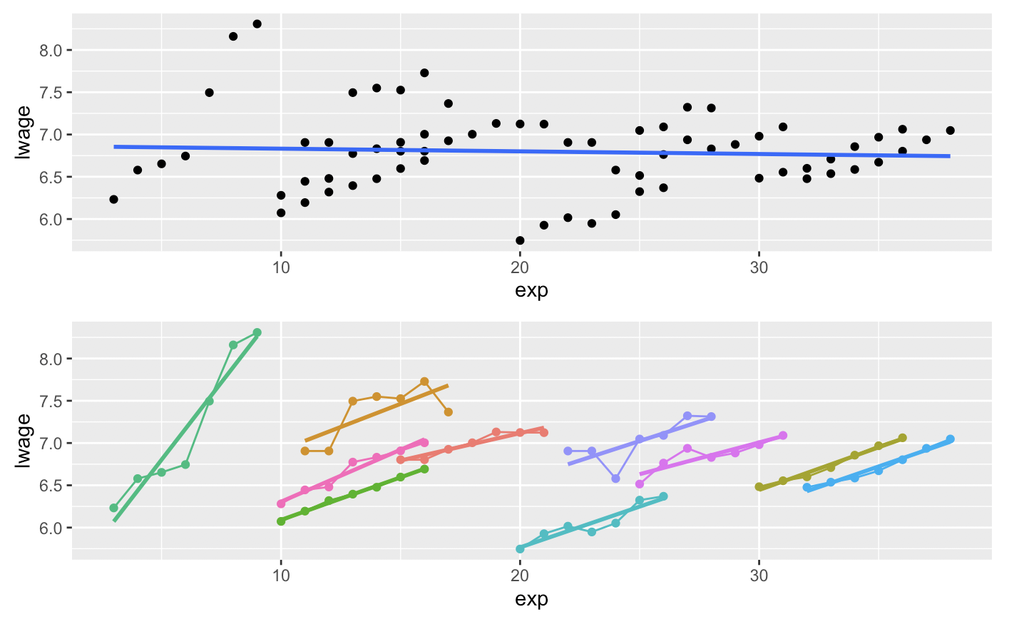

1. Sample ten persons from the dataset;
2. Create an “aggregate trend” scatter plot of these individuals across all observation years with an OLS regression line for the variable `exp` and `lwage` (the upper panel);
3. Similarly, create an “individual trend” scatter plot (the lower panel);
4. Arrange the two plots using `grid.arrange()`, post your plot to Slack;
5. How does the relationship between `exp` and `lwage` differ in these two plots? What would be the possible reasons for the difference?

Note: Due to sample randomness, it is okay if your plots look different from the example. It is also fine if your plot has legends.

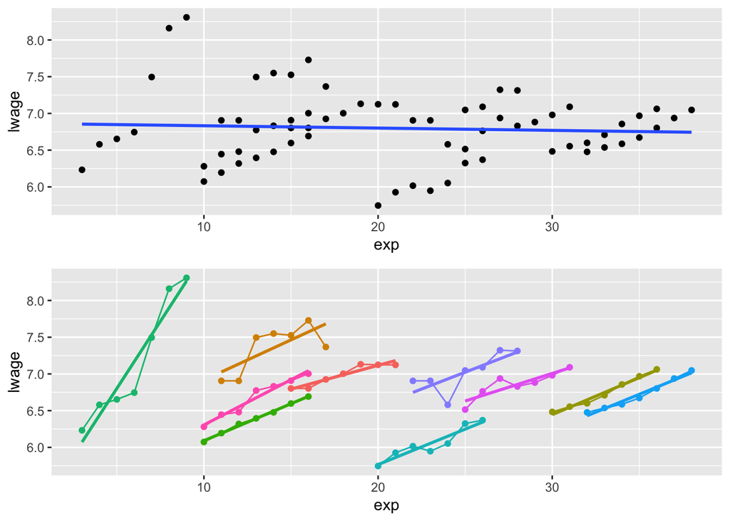

```r
# sample pid
set.seed(930412)
pid_sample <- sample(1:595, 10, replace = FALSE)

# Look at aggregate trend
fig1 <- Wages_clean %>%
  filter(pid %in% pid_sample) %>%
  ggplot(aes(x = exp, y = lwage)) +
  geom_point() +
  geom_smooth(method = "lm", se = F)

# Look at individual trend
fig2 <- Wages_clean %>%
  filter(pid %in% pid_sample) %>%
  ggplot(aes(x = exp, y = lwage, color = as.factor(pid), group = as.factor(pid))) +
  geom_point() +
  geom_line() +
  geom_smooth(method = "lm", se = F) +
  theme(legend.position = "none")

grid.arrange(fig1, fig2)
```

## Part 2 Fixed Effects and Random Effects Models

### Part 2 Exercise

Try to recreate the figure below that demonstrates the three different model curves by each individual’s pid. Make sure that you run all the code chunks before this question to ensure you have necessary objects in your R environment. Then, to simplify the steps, you can create a dataframe that is ready for plotting using the code provided in the following code chunk.

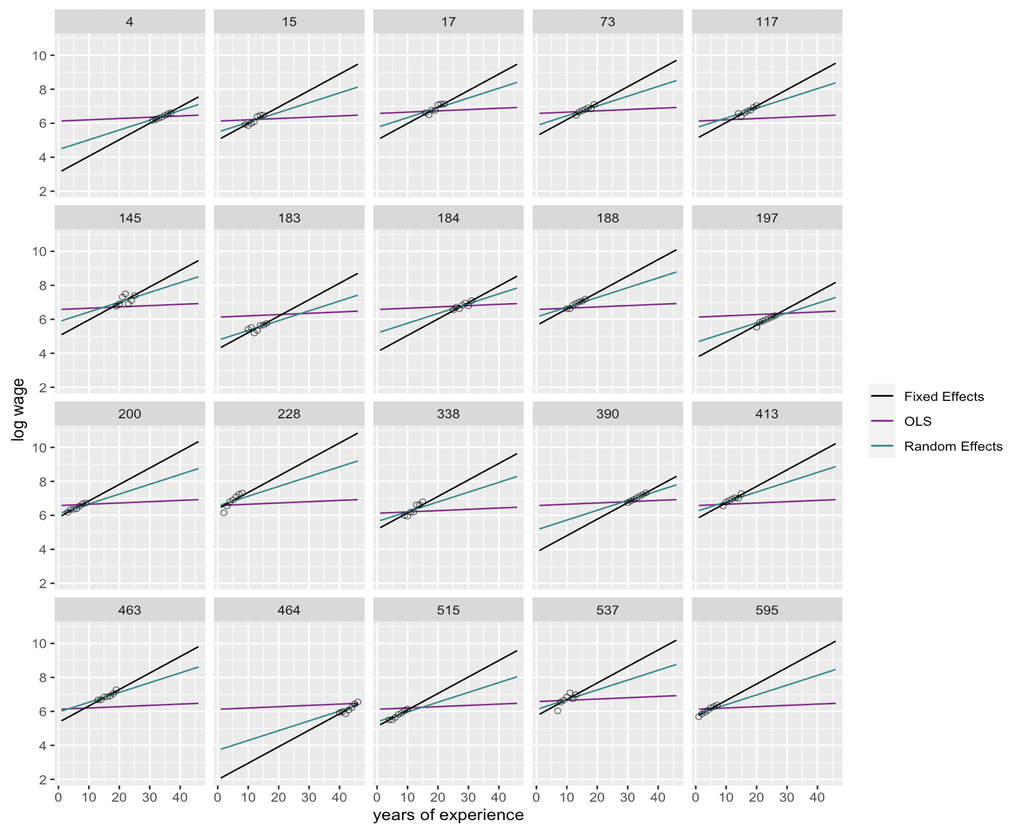

```r
# Prepare df for combine
predict_fe_temp <- predict_fe %>%
  dplyr::select(pid, exp, sex, fit) %>%
  rename(yhat_fe = fit)

predict_re_temp <- predict_re %>%
  dplyr::select(pid, exp, sex, yhat_re)

predict_ols_temp <- predict_ols %>%
  dplyr::select(exp, sex, fit) %>%
  rename(yhat_ols = fit)

# Combine yhat of three models
predict_combine <- predict_fe_temp %>%
  full_join(predict_re_temp, by = c("pid", "exp", "sex")) %>%
  left_join(predict_ols_temp, by = c("exp", "sex")) %>%
  left_join(Wages_sample, by = c("pid", "exp", "sex"))
```

Your code for plotting below:

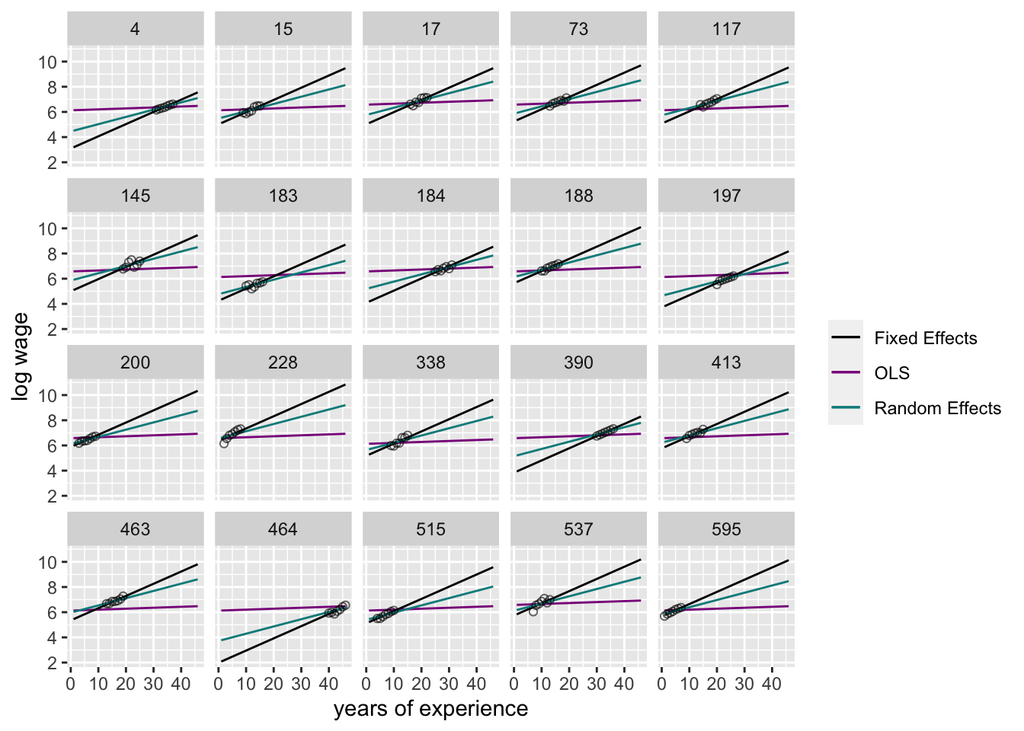

```r
# Plot
predict_combine %>%
  ggplot() +
  geom_line(aes(x = exp, y = yhat_ols, color = "OLS")) +
  geom_line(aes(x = exp, y = yhat_fe, color = "Fixed Effects")) +
  geom_line(aes(x = exp, y = yhat_re, color = "Random Effects")) +
  geom_point(aes(x = exp, y = lwage), shape = 1, alpha = 0.6) +
  facet_wrap(.~pid) +
  scale_colour_manual(name = "", values = c("black", "darkmagenta", "darkcyan")) +
  labs(x = "years of experience", y = "log wage")
```